# Reproducible Research: Peer Assessment 1

## Loading and preprocessing the data

For this part of the assignment we will:

1. Load the data (i.e. read.csv()) from the internet
2. Process/transform the data (if necessary) into a format suitable for analysis

The data for this assignment can be found at the following url as a zip file containing the **activity.csv** file in csv file format:

- Url: *https://d396qusza40orc.cloudfront.net/repdata%2Fdata%2Factivity.zip*
- File: *activity.csv*

The variables included in this dataset are:

- **steps**: Number of steps taking in a 5-minute interval (missing values are coded as ‘NA’)
- **date**: The date on which the measurement was taken in YYYY-MM-DD format
- **interval**: Identifier for the 5-minute interval in which measurement was taken

### Loading the data

The following code will be used to download and read the data into the `activity` data frame:

```r
temp <- tempfile()
download.file("https://d396qusza40orc.cloudfront.net/repdata%2Fdata%2Factivity.zip", temp, method="curl")
activity <- read.csv(unz(temp, "activity.csv"))
unlink(temp)
```

### Analyzing data contents

Let’s take a look at the structure and the first few rows in the data loaded:

```r
str(activity)
```

```
## 'data.frame':    17568 obs. of  3 variables:
##  $ steps   : int  NA NA NA NA NA NA NA NA NA NA ...
##  $ date    : Factor w/ 61 levels "2012-10-01","2012-10-02",..: 1 1 1 1 1 1 1 1 1 1 ...
##  $ interval: int  0 5 10 15 20 25 30 35 40 45 ...
```

```r
head(activity)
```

```
##   steps       date interval
## 1    NA 2012-10-01        0
## 2    NA 2012-10-01        5
## 3    NA 2012-10-01       10
## 4    NA 2012-10-01       15
## 5    NA 2012-10-01       20
## 6    NA 2012-10-01       25
```

### Preprocessing the data

In order to be able to work with date and time functions to aggregate and plot the data, a new variable, calles `datetime` will be created in the `activity` data frame with the date & time of each of the 5 minutes intervals, in the POSIXct format:

```r
activity$datetime<-as.POSIXct(strptime(paste(activity$date, formatC(activity$interval, width=4, flag="0")), "%Y-%m-%d %H%M"))
```

## What is mean total number of steps taken per day?

For this part of the assignment we will:

1. Make a histogram of the total number of steps taken each day
2. Calculate and report the mean and median total number of steps taken per day

### Histogram

In order to answer this question, we will create a new variable, called `stepsperday`, with the sum of the number of steps taken each day, being careful to:  
- Use the correct time zone (defult is UTC), and  
- Keep missing values so we can compute the mean correctly with the `mean` function with the parameter `na.rm=TRUE`.

```r
stepsperday<-aggregate(activity$steps, by=list(as.Date(activity$datetime, tz="")), FUN=sum, na.rm=F)

names(stepsperday)<-c("Date", "Steps")
```

Let’s view in a bar chart the total steps taken each day:

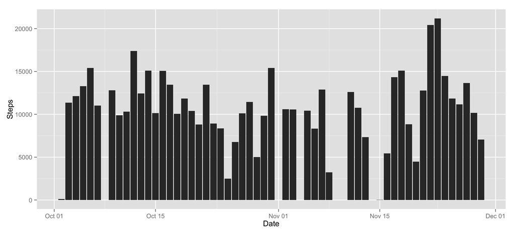

```r
library(ggplot2)
h<-ggplot(stepsperday, aes(Date, Steps))+geom_bar(stat="identity")
print(h)
```

### Mean and median number of steps

Let’s calculate the mean and meadian of total number of steps taken each day:

```r
Mean <- as.integer(mean(stepsperday$Steps, na.rm=TRUE))

Median <- as.integer(median(stepsperday$Steps, na.rm=TRUE))

Mean
```

```
## [1] 10766
```

```r
Median
```

```
## [1] 10765
```

> The daily mean of total steps taken is 10766 and the median is 10765!

## What is the average daily activity pattern?

For this part of the assigment, we will:

1. Make a time series plot (i.e. type = “l”) of the 5-minute interval (x-axis) and the average number of steps taken, averaged across all days (y-axis)
2. Which 5-minute interval, on average across all the days in the dataset, contains the maximum number of steps?

### Plot of average number of steps for each interval

First we will create a new data frame called `stepsperinterval` with the aggregate of the mean of the `activity$steps`, by `activity$interval` converted into a date format with the same date.

```r
Time<-as.POSIXct(strptime(formatC(activity$interval, width=4, flag="0"), "%H%M"))
stepsperinterval<-aggregate(activity$steps, by=list(Time), FUN=mean, na.rm=TRUE)
names(stepsperinterval)<-c("Time", "Steps")
```

Now let’s plot the `stepsperinterval` data:

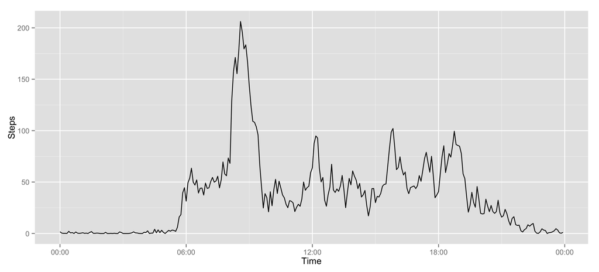

```r
library(ggplot2)
library(scales)
p<-ggplot(stepsperinterval, aes(Time, Steps))+geom_line()+scale_x_datetime(labels=date_format("%H:%M"))
print(p)
```

### Interval with largest number of steps

For the second question of this part of the assignment:

```r
Time <- strftime(stepsperinterval[order(stepsperinterval$Steps, decreasing=TRUE),][1,1], "%H:%M")
MaxSteps <- stepsperinterval[order(stepsperinterval$Steps, decreasing=TRUE),][1,2]

stepsperinterval[order(stepsperinterval$Steps, decreasing=TRUE),][1,]
```

```
##                    Time Steps
## 104 2014-08-17 08:35:00 206.2
```

> We can see that the 5-minute interval, on average across all the days in the dataset, that contains the maximum number of steps is 08:35 with an average number of steps of 206.1698!

## Imputing missing values

For this part of the assignment we shall:

1. Calculate and report the total number of missing values in the dataset (i.e. the total number of rows with NAs)
2. Devise a strategy for filling in all of the missing values in the dataset. The strategy does not need to be sophisticated. For example, you could use the mean/median for that day, or the mean for that 5-minute interval, etc.
3. Create a new dataset that is equal to the original dataset but with the missing data filled in.
4. Make a histogram of the total number of steps taken each day and Calculate and report the mean and median total number of steps taken per day. Do these values differ from the estimates from the first part of the assignment? What is the impact of imputing missing data on the estimates of the total daily number of steps?

### Missing values

Exploring the `activity` data loaded with the `summary` function:

```r
summary(activity)
```

```
##      steps               date          interval
##  Min.   :  0.0   2012-10-01:  288   Min.   :   0
##  1st Qu.:  0.0   2012-10-02:  288   1st Qu.: 589
##  Median :  0.0   2012-10-03:  288   Median :1178
##  Mean   : 37.4   2012-10-04:  288   Mean   :1178
##  3rd Qu.: 12.0   2012-10-05:  288   3rd Qu.:1766
##  Max.   :806.0   2012-10-06:  288   Max.   :2355
##  NA's   :2304    (Other)   :15840
##     datetime
##  Min.   :2012-10-01 00:00:00
##  1st Qu.:2012-10-16 05:43:45
##  Median :2012-10-31 12:27:30
##  Mean   :2012-10-31 12:27:30
##  3rd Qu.:2012-11-15 18:11:15
##  Max.   :2012-11-30 23:55:00
##  NA's   :12
```

```r
MissValues<-sum(is.na(activity$steps))
```

> We can see that the **steps** variable has missing values with a total of **2304**.

Let’s analyze how the **steps** variable missing data is distributed by date:

```r
table(activity$date, is.na(activity$steps))
```

```
##
##              FALSE TRUE
##   2012-10-01     0  288
##   2012-10-02   288    0
##   2012-10-03   288    0
##   2012-10-04   288    0
##   2012-10-05   288    0
##   2012-10-06   288    0
##   2012-10-07   288    0
##   2012-10-08     0  288
##   2012-10-09   288    0
##   2012-10-10   288    0
##   2012-10-11   288    0
##   2012-10-12   288    0
##   2012-10-13   288    0
##   2012-10-14   288    0
##   2012-10-15   288    0
##   2012-10-16   288    0
##   2012-10-17   288    0
##   2012-10-18   288    0
##   2012-10-19   288    0
##   2012-10-20   288    0
##   2012-10-21   288    0
##   2012-10-22   288    0
##   2012-10-23   288    0
##   2012-10-24   288    0
##   2012-10-25   288    0
##   2012-10-26   288    0
##   2012-10-27   288    0
##   2012-10-28   288    0
##   2012-10-29   288    0
##   2012-10-30   288    0
##   2012-10-31   288    0
##   2012-11-01     0  288
##   2012-11-02   288    0
##   2012-11-03   288    0
##   2012-11-04     0  288
##   2012-11-05   288    0
##   2012-11-06   288    0
##   2012-11-07   288    0
```

[output cut: 8 more lines]

```
##   2012-11-16   288    0
##   2012-11-17   288    0
##   2012-11-18   288    0
##   2012-11-19   288    0
##   2012-11-20   288    0
##   2012-11-21   288    0
##   2012-11-22   288    0
##   2012-11-23   288    0
##   2012-11-24   288    0
##   2012-11-25   288    0
##   2012-11-26   288    0
##   2012-11-27   288    0
##   2012-11-28   288    0
##   2012-11-29   288    0
##   2012-11-30     0  288
```

We can see that we have 288 measurements each day, since there are 12 x 5 minutes intervals in an hour and 288 x 5 minutes intervals in a day.  
From a total of 61 days with steps measurements, we have data missing from 8 whole days. The other days have complete steps measurements.  
The days that do not have measurements are:

```r
unique(activity[is.na(activity$steps),2])
```

```
## [1] 2012-10-01 2012-10-08 2012-11-01 2012-11-04 2012-11-09 2012-11-10
## [7] 2012-11-14 2012-11-30
## 61 Levels: 2012-10-01 2012-10-02 2012-10-03 2012-10-04 ... 2012-11-30
```

### Filling missing values and creating a new dataset

We will fill the missing values for the number os steps taken with the **mean of the interval**.

Let’s aggregate the `activity` dataset into `stepsperinterval` variable by interval.

```r
stepsperinterval<-aggregate(activity$steps, by=list(activity$interval), FUN=mean, na.rm=TRUE)
names(stepsperinterval)<-c("interval", "avgsteps")
```

Now let’s create the `activity2` dataset as the merger of `activity` and `stepsperinterval` dataset by the `interval` value, and move the `avgsteps` values to the missing `interval` values.

```r
activity2<-merge(activity, stepsperinterval)
nulls<-is.na(activity2$steps)
activity2[nulls,]$steps<-activity2[nulls,]$avgsteps
```

### Analysing the new dataset

Let’s redo the calculations using the new dataset:

```r
stepsperday2<-aggregate(activity2$steps, by=list(as.Date(activity2$datetime, tz="")), FUN=sum, na.rm=F)

names(stepsperday2)<-c("Date", "Steps")
```

Let’s view in a bar chart the total steps taken each day:

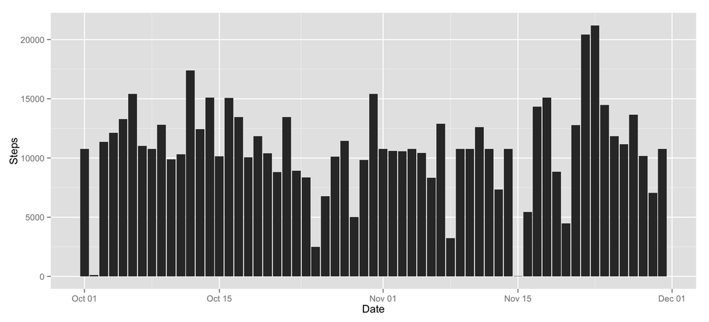

```r
library(ggplot2)
h<-ggplot(stepsperday2, aes(Date, Steps))+geom_bar(stat="identity")
print(h)
```

Let’s calculate the mean and meadian of total number of steps taken each day:

```r
Mean2 <- as.integer(mean(stepsperday2$Steps, na.rm=TRUE))

Median2 <- as.integer(median(stepsperday2$Steps, na.rm=TRUE))

Mean2
```

```
## [1] 10766
```

```r
Median2
```

```
## [1] 10766
```

> The new daily mean of total steps taken is 10766 while the old one was 10766, and the new median is 10766 while the old one is 10765!  
> **So the data we have filled in for the missing values did not make a considerable impact in the mean and median of the total number of steps taken each day!**

## Are there differences in activity patterns between weekdays and weekends?

For this part of the assignment, we will use the dataset with the filled-in missing values (`activity2`) to:

1. Create a new factor variable in the dataset with two levels – “weekday” and “weekend” indicating whether a given date is a weekday or weekend day.
2. Make a panel plot containing a time series plot (i.e. type = “l”) of the 5-minute interval (x-axis) and the average number of steps taken, averaged across all weekday days or weekend days (y-axis).

### New variable

We will create a factor variable called `weekday` in the `activity2` data set with the following code:

```r
## Variable with the day of the week
activity2$dayoftheweek<-weekdays(activity2$datetime, abbreviate=TRUE)

## Data frame with the day of the week and if it is a weekday or a weekend
dayoftheweek<-c("Mon","Tue","Wed","Thu","Fri","Sat","Sun")
weekday<-c("weekday","weekday","weekday","weekday","weekday","weekend","weekend")
w<-as.data.frame(cbind(dayoftheweek, weekday))

## Merge w to activity2 after fixing bug in R with 2012-10-21 datetime.
activity2[is.na(activity2$dayoftheweek),]$dayoftheweek<-c("Sun") # bug fix
activity2<-merge(activity2, w)
```

### Plot comparing average steps on weekdays and weekends

Create an aggregate dataset from `activity2` with the mean of the number of steps by interval and by the factor weekday:

```r
stepsperinterval2<-aggregate(activity2$steps, by=list(activity2$interval, activity2$weekday), FUN=mean, na.rm=TRUE)
names(stepsperinterval2)<-c("Interval", "weekday", "Steps")
```

Now let’s plot this dataset:

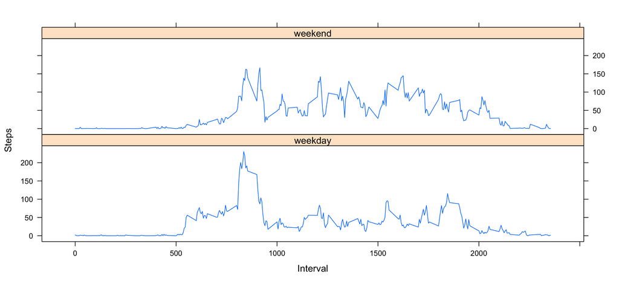

```r
library(lattice)
xyplot(Steps ~ Interval | weekday, data=stepsperinterval2, layout=c(1,2), type="l")
```

> **Apparently during the weekends more steps are taken after around 10 AM, while during week days there are more steps taken between 8AM and 10AM!**